# Taller 2: Lab 1: Introducción a la inferencia de aleatorización

# 1 Randomization Inference

La inferencia de aleatorización (RI) es un procedimiento para realizar pruebas de hipótesis en experimentos aleatorios. RI es útil para calcular la probabilidad de que:

- una estadística de prueba sería tan extrema o más como se observa…
- si una hipótesis nula particular fuera cierta…
- sobre todas las posibles aleatorizaciones que podrían haber ocurrido según el diseño .

A esa probabilidad a veces se le llama p-valor.

## 1.1 Paquete `ri2`

Gerber y Green (2012) describen un experimento hipotético en el que a 2 de 7 aldeas se les asigna una jefa de consejo y el resultado es la parte del presupuesto local asignada al saneamiento del agua. Su tabla 2.2 describe una forma en que podría haber resultado el experimento.

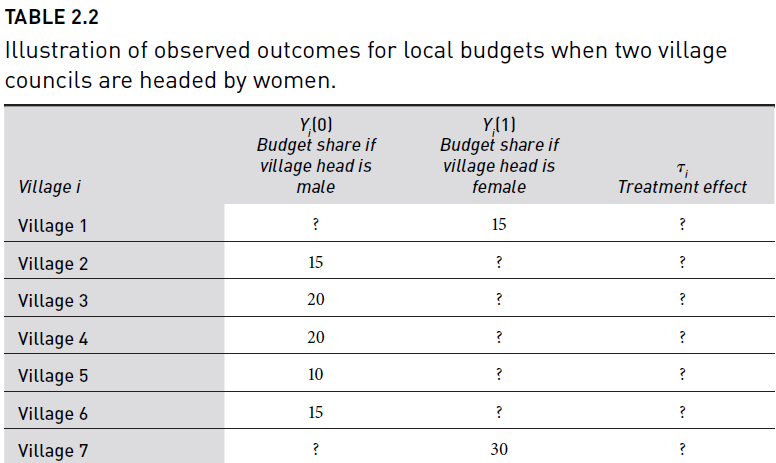

```r
table_2_2 <- data.frame(Z = c(1, 0, 0, 0, 0, 0, 1), Y = c(15,
    15, 20, 20, 10, 15, 30))

table_2_2
```

```
##   Z  Y
## 1 1 15
## 2 0 15
## 3 0 20
## 4 0 20
## 5 0 10
## 6 0 15
## 7 1 30
```

Cargamos la librería:

```r
# install.packages('ri2')
library(ri2)
```

Para realizar una inferencia de aleatorización debemos proporcionar

1. una estadística de prueba
2. una hipótesis nula
3. un procedimiento de aleatorización

**La estadística de prueba**. El argumento `formula` de la función `conduct_ri` tiene una sintaxis análoga a la función `lm` o a la expresión de `formula` en R. El estadístico de prueba es el coeficiente Z de una regresión de Y en Z, en concreto, la diferencia de medias.

**La hipótesis nula**. El argumento `sharp_hypothesis` de la función `conduct_ri` indica que estamos imaginando un mundo en el que la verdadera diferencia en los resultados potenciales es exactamente 0 para todas las unidades.

**El procedimiento de aleatorización**. La funcion `declare_rafunción` del paquete `randomizr` permite declarar un procedimiento de aleatorización. En este caso, estamos asignando 2 unidades a tratamiento sobre un total de unidades.

#### 1.1.0.1 Paso a paso

Se declarar procedimiento de aleatorización

```r
declaration <- randomizr::declare_ra(N = 7, m = 2)

declaration
```

```
## Random assignment procedure: Complete random assignment
## Number of units: 7
## Number of treatment arms: 2
## The possible treatment categories are 0 and 1.
## The number of possible random assignments is 21.
## The probabilities of assignment are constant across units:
##    prob_0    prob_1
## 0.7142857 0.2857143
```

#### 1.1.0.2 Interpretación

**2. Number of units: 7**  
La cantidad total de unidades (por ejemplo, personas, grupos o elementos) a asignar es **7**.

**3. Number of treatment arms: 2**  
Hay **2 grupos** o categorías de asignación posibles:

- **0:** Grupo de control (no recibe tratamiento).
- **1:** Grupo de tratamiento (recibe la intervención o tratamiento).

**4. The possible treatment categories are 0 and 1**  
Las dos categorías de tratamiento son **0** y **1**, donde:

- **0** representa el grupo de control.
- **1** representa el grupo de tratamiento.

**5. The number of possible random assignments is 21.**  
Hay **21 formas posibles** de asignar 2 unidades al grupo de tratamiento y 5 al grupo de control.  
Esto se debe a que $C(7,2) = 21$, es decir, las combinaciones de 7 elementos tomados de 2 en 2.

**6. The probabilities of assignment are constant across units:**  
La probabilidad de ser asignado a cada grupo es constante para todas las unidades:

- **prob_0 (Control):** 0.714 (5 de las 7 unidades se asignan al grupo de control).
- **prob_1 (Tratamiento):** 0.286 (2 de las 7 unidades se asignan al grupo de tratamiento).

Como la asignación es completa y fija en términos de números, cada unidad tiene esas probabilidades asignadas, con la distribución ya definida de 5 en control y 2 en tratamiento.

#### 1.1.0.3 En suma

Este proceso implica que estamos realizando una **asignación aleatoria completa** de 7 unidades, donde **exactamente 2** unidades recibirán tratamiento y **5** no lo recibirán. El número de posibles combinaciones para distribuir esas 2 unidades en el grupo de tratamiento es **21**. Además, cada unidad tiene una probabilidad constante del 71.4% de estar en control y 28.6% de estar en tratamiento.

### 1.1.1 Cálculo Manual

```r
N = 7
m = 2
(p_0 = (N - m)/N)
```

```
## [1] 0.7142857
```

```r
(p_1 = 1 - p_0)
```

```
## [1] 0.2857143
```

```r
combinaciones <- choose(N, m)
combinaciones
```

```
## [1] 21
```

### 1.1.2 Inferencia

**Descripción del Proceso**

- **Hipótesis Nula:**En este caso, la hipótesis nula es que el tratamiento no tiene efecto alguno sobre la variable de respuesta (Y). Específicamente, la función prueba la hipótesis “efecto = 0” (por el argumento sharp_hypothesis = 0).
- **Permutaciones Aleatorias:**
  - `conduct_ri()` genera muchas permutaciones aleatorias del tratamiento (variable Z en este caso) para calcular la distribución de los resultados bajo la hipótesis nula.
  - Luego compara el estimador real con esta distribución generada aleatoriamente para calcular el valor p (proporción de permutaciones donde los resultados simulados son al menos tan extremos como el observado).

```r
ri2_out <- conduct_ri(formula = Y ~ Z, declaration = declaration,
    sharp_hypothesis = 0, data = table_2_2)
```

Observamos el resumen

```r
summary(ri2_out)
```

```
##   term estimate two_tailed_p_value
## 1    Z      6.5          0.3809524
```

###### 1.1.2.0.0.1 Interpretación del Output

**`term`:**  
- La variable independiente o **tratamiento** es `Z`. Esta es la variable que se manipuló en el experimento (por ejemplo, si las unidades recibieron tratamiento o no).

**`estimate`:**  
- El **estimado del efecto del tratamiento** es **6.5**. Esto sugiere que, en promedio, las unidades en el grupo de tratamiento tuvieron un valor 6.5 unidades mayor en la variable de resultado (`Y`) en comparación con las unidades en el grupo de control.

**`two_tailed_p_value`:**  
- El **valor p** es **0.3809524**.  
Este valor indica la probabilidad de observar un efecto tan extremo (o más extremo) que 6.5, **si la hipótesis nula fuera cierta** (es decir, si no hubiera ninguna diferencia real entre los grupos de tratamiento y control).

###### 1.1.2.0.0.2 En suma

- Con un **valor p de 0.381**, **no hay suficiente evidencia para rechazar la hipótesis nula** al nivel de significancia común de 0.05. Esto significa que no se puede afirmar, con un alto nivel de confianza, que el tratamiento (Z) tenga un efecto significativo en la variable de resultado (Y).
- Aunque el estimado del efecto es positivo (6.5), podría deberse al azar, ya que el valor p es relativamente alto.

Visualizamos

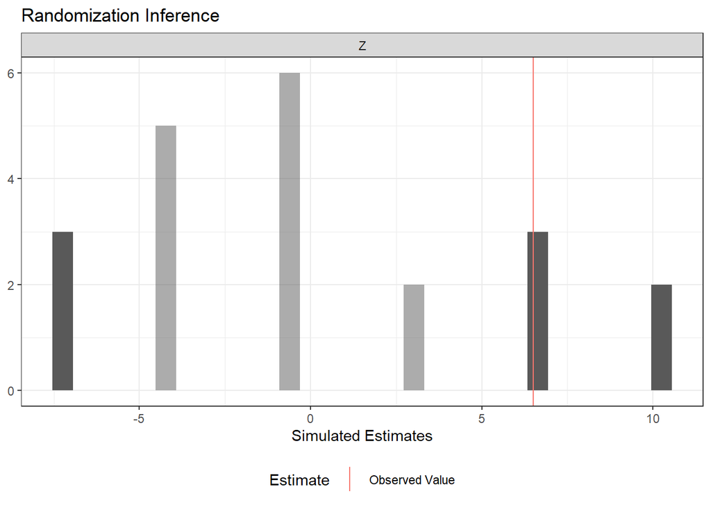

```r
plot(ri2_out)
```

## 1.2 Procedimiento manual

```r
# Datos del experimento
tratadas <- c(15, 30)  # Datos de las unidades tratadas
no_tratadas <- c(15, 20, 20, 10, 15)  # Datos de las unidades no tratadas

# Estadística observada: Diferencia en medias
estadistica_obs <- mean(tratadas) - mean(no_tratadas)
estadistica_obs
```

```
## [1] 6.5
```

```r
# Combinar datos
datos_combinados <- c(tratadas, no_tratadas)

# Número de permutaciones
num_permutaciones <- 10000

# Vector para almacenar las estadísticas permutadas
estadisticas_permutadas <- numeric(num_permutaciones)

set.seed(42)
for (i in 1:num_permutaciones) {
    datos_permutados <- sample(datos_combinados, replace = FALSE)
    estadisticas_permutadas[i] <- mean(datos_permutados[1:2]) -
        mean(datos_permutados[3:7])
}

# p-valor
valor_p <- mean(abs(estadisticas_permutadas) >= abs(estadistica_obs))

valor_p
```

```
## [1] 0.3836
```

Visualizamos el resultado:

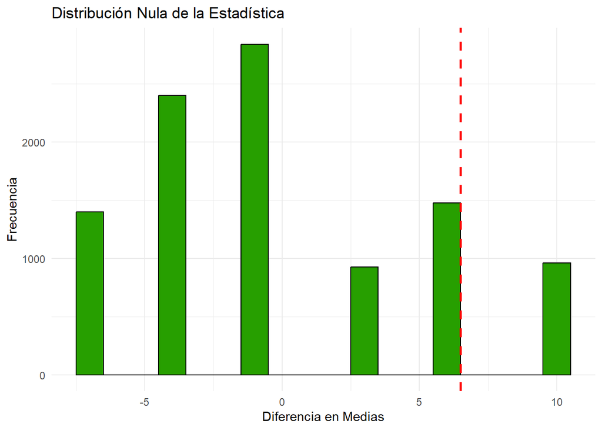

```r
library(ggplot2)

ggplot(data.frame(estadisticas_permutadas), aes(x = estadisticas_permutadas)) +
    geom_histogram(binwidth = 1, fill = "#279F00", color = "black") +
    geom_vline(xintercept = estadistica_obs, color = "red", linetype = "dashed",
        size = 1) + labs(title = "Distribución Nula de la Estadística",
    x = "Diferencia en Medias", y = "Frecuencia") + theme_minimal()
```

## 1.3 Ejercicio

Utilizando los siguientes [datos](https://raw.githubusercontent.com/egap/methods-guides/master/ri2/complete_dat.csv) declare un diseño de asignación aleatoria completo y realice la inferencia de aleatorización y visualice el resultado.

```r
## por ejemplo puede cargar los datos de la siguiente
## manera

## rio::import(url)
```